# case2

Richard Gan

2024-12-08

# 1 Introduction

Sector: Transportation Services Companies: MacroAsia Corporation (PSE:MAC) and International Container Terminal Services, Inc. (PSE:ICT) Interpretation: Interpretation is commented on last line(s) of each code chunk Note: For MacroAsia (MAC) price was used to model. This is to provide further analysis since Log Returns model generates ARIMA(0,0,0). Stationary data may have caused it.

# 2 MAC Background

MacroAsia Corporation (MAC), through its subsidiaries and associates, is engaged in aviation-support businesses at the Ninoy Aquino International Airport (NAIA), Manila Domestic Airport, Mactan-Cebu International Airport, Kalibo International Airport, Davao International Airport, and the General Aviation Areas. The group provides aircraft maintenance, repairs and overhaul services, in-flight catering services, airport ground handling services, charter flight services, and operates a special economic zone at the NAIA.

# 3 ICT Background

International Container Terminal Services, Inc. (ICT) was incorporated on December 24, 1987 to operate, manage and develop the Manila International Container Terminal (MICT), which handles international container cargo at the Port of Manila. ICT provide ancillary services such as storage, container stripping and stuffing, inspection, weighing and services for refrigerated containers or reefers, as well as roll-on/roll-off and anchorage services to non-containerized cargoes or general cargoes on a limited basis.

```r
pacman::p_load(tseries,quantmod,forecast,timeSeries,FinTS,rugarch,dplyr,PerformanceAnalytics,readxl,xts,tsm,remotes,fpp3, ggplot2, urca, plotly, ggfortify)
remotes::install_github("KevinKotze/tsm")
```

# 4 PART 1: Data Preparation

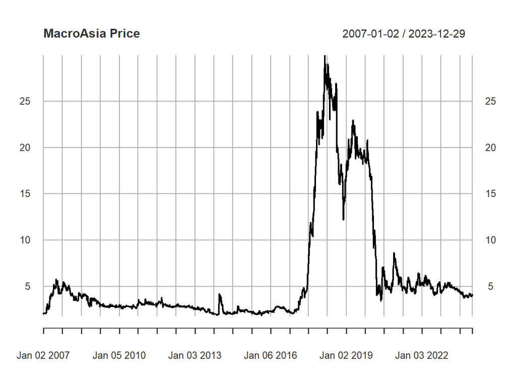

```r
# Load MacroAsia
mdata <- read_excel('MAC.xlsx', sheet = 'Sheet 1')

# XTS Conversion
mdata <- data.frame(date = as.Date(mdata$date), value = mdata$close)
mdata <- xts(mdata$value, order.by = mdata$date)
mdata <- na.omit(mdata)
plot(mdata, main = 'MacroAsia Price')
```

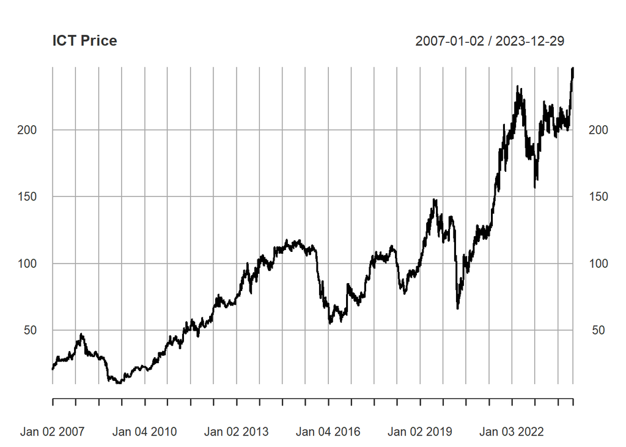

```r
idata <- read_excel('ICT.xlsx', sheet = 'Sheet 1')

# XTS Conversion
idata <- data.frame(date = as.Date(idata$date), value = idata$close)
idata <- xts(idata$value, order.by = idata$date)
plot(idata, main = 'ICT Price')
```

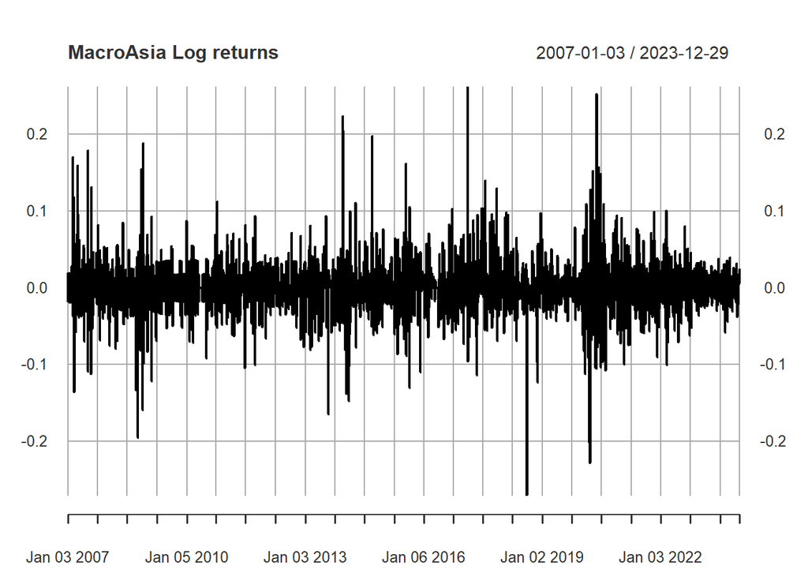

```r
mdata_ret <- na.omit(diff(log(mdata)))
plot(mdata_ret,main = 'MacroAsia Log returns')
```

```r
# volatility clustering around 2017 and 2020 hence ARIMA not sufficient model
```

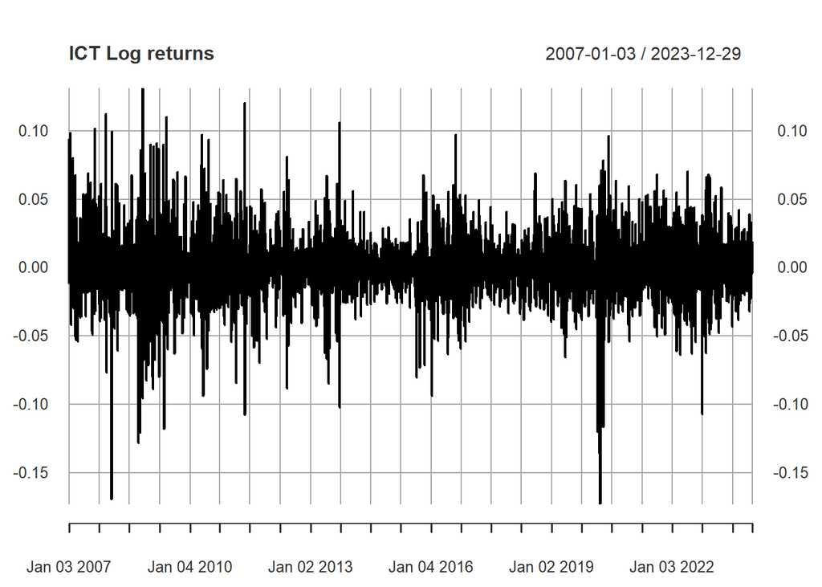

```r
idata_ret <- na.omit(diff(log(idata)))
plot(idata_ret, main = 'ICT Log returns')
```

```r
# volatility clustering around 2008 and 2020
```